# 501 Project (Naive Bayes)

Zijing Cheng(Mavis, zc233)

### Prepare Data for Naïve Bayes in Python

```python
import pandas as pd
df = pd.read_csv("data/01-modified-data/textcleaning_py.csv")
```

#### Let's take a look of our labeled text data as it shows below.

```python
df.head()
```

|  | id | retweet_count | retweeted | Clean_Text |
| --- | --- | --- | --- | --- |
| 0 | 1570097774930132992 | 1060 | True | rt nickiminaj let hope ppl guy r dirty work lo... |
| 1 | 1570097774355709954 | 0 | False | ciaoszn charity work ☺ ️ ☺ ️ ☺ ️ |
| 2 | 1570097773839630337 | 53 | True | rt marii_chaudhry congratulations team wepatri... |
| 3 | 1570097773697015808 | 179 | True | rt fact not wish work |
| 4 | 1570097773672042498 | 161 | True | rt jeonmanwon seungcheol suspicious like puppe... |

#### Data preparation includes extracting dependent variable, retweeted, whether the tweet is retweeted or not and texts as input. And it also includes the process of spliting training and testing sets. We split the labeled text data into train and test with 70% trainning ratio.

```python
from sklearn.model_selection import train_test_split
```

```python
X_train, X_test, y_train, y_test = train_test_split(df["Clean_Text"], df["retweeted"], test_size=0.3, random_state=0)
```

#### In this method, the assumption of Naive Bayes assumption is that each feature makes an independent and equal contribution to the outcome. And when it comes to texts, we have a concept, which is bag of words as we treat each token independent, conditioned on class label. So we must count vectorizer our texts to get the matrix for maximizing the likelihood.

#### The first step is count vectorizer

```python
# count vectorizer
from sklearn.feature_extraction.text import CountVectorizer
countvect = CountVectorizer()
Xtraincount = countvect.fit_transform(X_train)
Xtraincount.shape
```

```
(70, 476)
```

#### The second step is to get Term Frequency times Inverse Document Frequency as it is a quick method to get the input word matrix.

```python
from sklearn.feature_extraction.text import TfidfTransformer
tf = TfidfTransformer(use_idf=False).fit(Xtraincount)
Xtraintf = tf.transform(Xtraincount)
Xtraintf.shape
```

```
(70, 476)
```

```python
tfidf = TfidfTransformer()
Xtraintfidf = tfidf.fit_transform(Xtraincount)
Xtraintfidf.shape
```

```
(70, 476)
```

#### It is the time to train a classifier

```python
from sklearn.naive_bayes import MultinomialNB
clf = MultinomialNB().fit(Xtraintfidf, y_train)
```

```python
# predict
Xtestcount = countvect.transform(X_test)
Xtesttfidf = tfidf.transform(Xtestcount)
predict = clf.predict(Xtesttfidf)
```

#### Evaluating the performance of a classification model, we need to evaluate our model using several different metrics.

#### One common issue is class imbalance, which is when the label distribution in the data varies far from uniform. In this case a high accuracy can be misleading because low frequency labels don't contribute equally to the score. More generally, one of the biggest drawbacks of using MLE in NLP, that is, models tend to be much less sensitive to low probability labels than to higher probabilty labels.

#### Another reason to use multiple evaluation methods is that it can help us better understand our data. Evaluating performance on individual classes often reveals problems with the data that would otherwise go unnoticed.

#### In this part we will use some metrics and visualization tools:

##### F1 score

##### The confusion matrix

```python
# Accuracy
from sklearn import metrics
metrics.accuracy_score(y_test,predict)
```

```
0.7666666666666667
```

```python
print("These below are results summaries")
print("----------------------")
print("Accuracy      0.7667")
print("ROC-AUC score 0.7083")
print("precision     0.83")
print("recall        0.77")
print("f1-score      0.74")
print("support       30")
print("----------------------")
```

```
These below are results summaries
----------------------
Accuracy      0.7667
ROC-AUC score 0.7083
precision     0.83
recall        0.77
f1-score      0.74
support       30
----------------------
```

```python
from sklearn import metrics
print(metrics.classification_report(y_test, predict))
```

```
              precision    recall  f1-score   support

       False       1.00      0.42      0.59        12
        True       0.72      1.00      0.84        18

    accuracy                           0.77        30
   macro avg       0.86      0.71      0.71        30
weighted avg       0.83      0.77      0.74        30
```

```python
print("-----------------------------")
print("This is the confusion matrix")
print("-----------------------------")
print(str(metrics.confusion_matrix(y_test, predict)))
```

```
-----------------------------
This is the confusion matrix
-----------------------------
[[ 5  7]
 [ 0 18]]
```

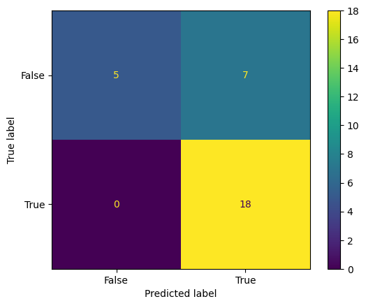

```python
from sklearn.metrics import plot_confusion_matrix
plot_confusion_matrix(clf, Xtesttfidf, y_test)
plt.show()
```

```python
Yscore = clf.predict_proba(Xtraintfidf)
from sklearn.metrics import roc_auc_score
from sklearn.preprocessing import LabelBinarizer
def class_roc_auc_score(Ytest, predict, average="macro"):
    lb = LabelBinarizer()
    lb.fit(Ytest)
    Ytest = lb.transform(Ytest)
    predict = lb.transform(predict)
    auc_values = roc_auc_score(Ytest, predict, average=average)
    return auc_values
class_roc_auc_score(y_test, predict)
```

```
0.7083333333333333
```

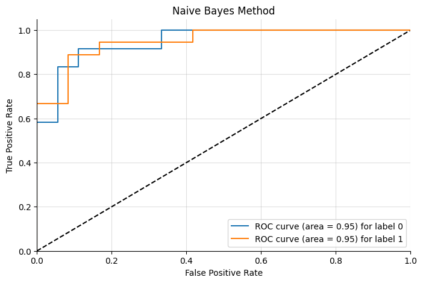

```python
import seaborn as sns
import matplotlib.pyplot as plt
def plot_multiclass_roc(clf, X_test, y_test, n_classes, figsize=(17, 6)):
    y_score = clf.predict_proba(X_test)

    # structures
    fpr = dict()
    tpr = dict()
    roc_auc = dict()

    # calculate dummies once
    y_test_dummies = pd.get_dummies(y_test, drop_first=False).values
    for i in range(n_classes):
        fpr[i], tpr[i], _ = metrics.roc_curve(y_test_dummies[:, i], y_score[:, i])
        roc_auc[i] = metrics.auc(fpr[i], tpr[i])

    # roc for each class
    fig, ax = plt.subplots(figsize=figsize)
    ax.plot([0, 1], [0, 1], 'k--')
    ax.set_xlim([0.0, 1.0])
    ax.set_ylim([0.0, 1.05])
    ax.set_xlabel('False Positive Rate')
    ax.set_ylabel('True Positive Rate')
    ax.set_title('Naive Bayes Method')
    for i in range(n_classes):
        ax.plot(fpr[i], tpr[i], label='ROC curve (area = %0.2f) for label %i' % (roc_auc[i], i))
    ax.legend(loc="best")
    ax.grid(alpha=.4)
    sns.despine()
    plt.show()

plot_multiclass_roc(clf, Xtesttfidf, y_test, n_classes=2, figsize=(8, 5))
```

### Email

zc233@georgetown.edu